# Midterm 2 - Dairy - STA 309

Will Paz

2024-04-18

### Read in the Data

```r
production <- read_csv("https://raw.githubusercontent.com/oconnellmj/sta309/main/milk-production-tonnes.csv")
consumption <- read_csv("https://raw.githubusercontent.com/oconnellmj/sta309/main/per-capita-milk-consumption.csv")
```

## Our Goal

In this problem, you will create a dashboard about dairy production and consumption around the world. The datasets for this problem come from the Food and Agriculture Organization of the United Nations and have been preprocessed by OurWorldInData.org.

Create a dashboard to study dairy production and consumption around the world. Among the plots, you must include the following:

- A map of dairy production
- A map of dairy consumption
- Changes in dairy production/consumption over time
- The relationship between dairy production and consumption
- At least 4 plots in the dashboard (the previous requirements will probably require 4 plots anyway!)

You should focus on telling a story about dairy production and consumption; annotations and subtitles can help focus the narrative! Apart from the above requirements, the assignment is very open-ended. Here are some things that you can consider:

- For the maps, are you interested in specific years (such as a recent year or recent years) or the average across all years in the data (1961-2022)?
- Do you want to look at the whole world, or focus on a specific region? Should you show maps at different time points? (This will likely lead to more than 4 plots, but it might help you present your narrative).

## Production Map

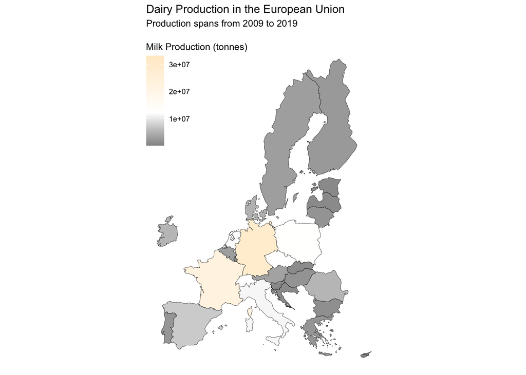

```r
eu_countries <- c("Austria", "Belgium", "Bulgaria", "Croatia", "Cyprus", "Czech Republic",
                  "Denmark", "Estonia", "Finland", "France", "Germany", "Greece",
                  "Hungary", "Ireland", "Italy", "Latvia", "Lithuania", "Luxembourg",
                  "Malta", "Netherlands", "Poland", "Portugal", "Romania", "Slovakia",
                  "Slovenia", "Spain", "Sweden")

production_eu <- production %>%
  filter(Entity %in% eu_countries,
         Year >= 2009,
         Year <= 2019)

world_map <- map_data("world")

world_map_prod_clean <- world_map %>%
  rename(Entity = region) %>%
  filter(Entity %in% unique(production_eu$Entity)) %>%
  select(!subregion)

production_map <- left_join(world_map_prod_clean,production_eu,by="Entity")
map1 <- ggplot(production_map, aes(x=long, y=lat, group=group) ) +
  geom_polygon(aes(fill=`Milk Production (tonnes)`),color="black",linewidth=.12) +
  scale_fill_gradient2(low="gray30",high="blanchedalmond",
                      midpoint=12000000) +
  coord_map() +
  theme_map() +
  theme(legend.position = c(-.02,.65),
        legend.background = element_rect(fill = "transparent")) +
  labs(title="Dairy Production in the European Union",
       subtitle = "Production spans from 2009 to 2019")
map1
```

## Consumption Map

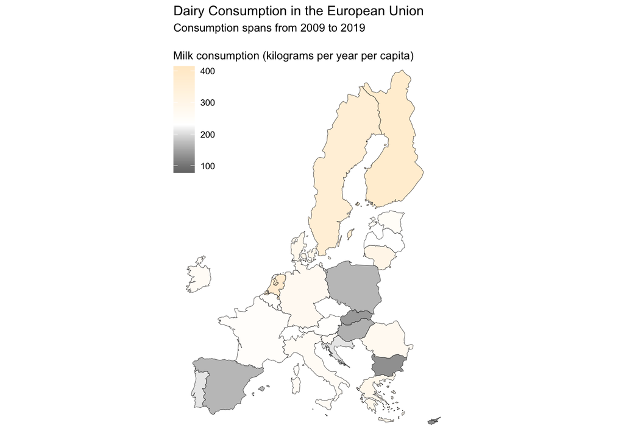

```r
consumption_eu <- consumption %>%
  filter(Entity %in% eu_countries,
         Year >= 2009,
         Year <= 2019)

world_map <- map_data("world")

world_map_consump_clean <- world_map %>%
  rename(Entity = region) %>%
  filter(Entity %in% unique(consumption_eu$Entity)) %>%
  select(!subregion)

consumption_map <- left_join(world_map_consump_clean,consumption_eu,by="Entity")
map2 <- ggplot(consumption_map, aes(x=long, y=lat, group=group) ) +
  geom_polygon(aes(fill=`Milk consumption (kilograms per year per capita)`),color="black",linewidth=.12) +
  scale_fill_gradient2(low="gray35",high="blanchedalmond",
                       midpoint = 230) +
  coord_map() +
  theme_map() +
  theme(legend.position = c(-.02,.65),
        legend.background = element_rect(fill = "transparent")) +
  labs(title="Dairy Consumption in the European Union",
       subtitle = "Consumption spans from 2009 to 2019")
map2
```

```r
production_eu %>%
  arrange(desc(`Milk Production (tonnes)`))
```

```
## # A tibble: 286 × 4
##    Entity  Code   Year `Milk Production (tonnes)`
##    <chr>   <chr> <dbl>                      <dbl>
##  1 Germany DEU    2018                   33109650
##  2 Germany DEU    2019                   33102570
##  3 Germany DEU    2015                   32707948
##  4 Germany DEU    2016                   32692340
##  5 Germany DEU    2017                   32616198
##  6 Germany DEU    2014                   32419494
##  7 Germany DEU    2013                   31350828
##  8 Germany DEU    2012                   30703816
##  9 Germany DEU    2011                   30354800
## 10 Germany DEU    2010                   29646032
## # ℹ 276 more rows
```

```r
consumption_eu %>%
  arrange(desc(`Milk consumption (kilograms per year per capita)`))
```

```
## # A tibble: 286 × 4
##    Entity      Code   Year `Milk consumption (kilograms per year per capita)`
##    <chr>       <chr> <dbl>                                              <dbl>
##  1 Malta       MLT    2014                                               415.
##  2 Finland     FIN    2009                                               380.
##  3 Netherlands NLD    2009                                               373.
##  4 Finland     FIN    2013                                               371.
##  5 Finland     FIN    2014                                               364.
##  6 Finland     FIN    2016                                               361.
##  7 Sweden      SWE    2009                                               358.
##  8 Finland     FIN    2017                                               356.
##  9 Finland     FIN    2012                                               354.
## 10 Finland     FIN    2018                                               352.
## # ℹ 276 more rows
```

## Dairy Production Over Time

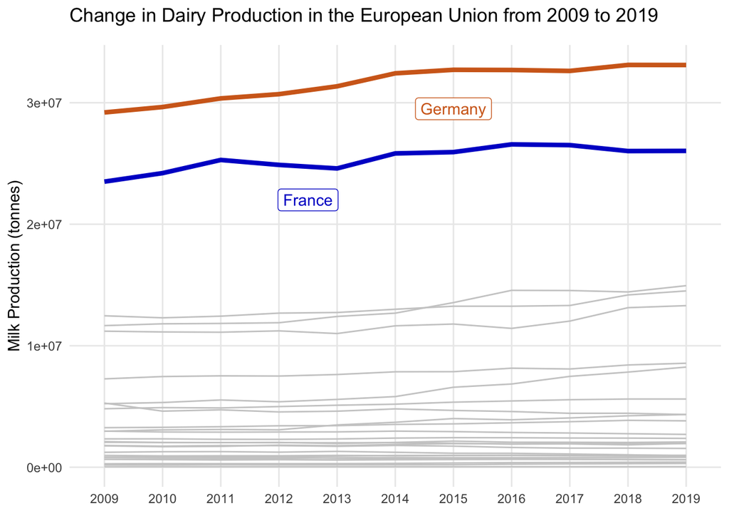

```r
chart1 <- ggplot() +
  geom_line(data=production_eu,aes(x=as.factor(Year),y=`Milk Production (tonnes)`,
                              group=Entity),color="gray80") +
  geom_line(data=filter(production_eu,Entity == "Germany"),
            aes(x=as.factor(Year),y=`Milk Production (tonnes)`, group=Entity),
            color="chocolate", linewidth=1.5) +
  geom_line(data=filter(production_eu,Entity == "France"),
            aes(x=as.factor(Year),y=`Milk Production (tonnes)`, group=Entity),
            color="mediumblue", linewidth=1.5) +
  theme_minimal() +
  labs(x=element_blank(),
       title="Change in Dairy Production in the European Union from 2009 to 2019",
       subtitle = element_blank()) +
  annotate("label", x = 7, y = 29500000, label = "Germany", color = "chocolate") +
  annotate("label", x = 4.5, y = 22000000, label = "France", color = "mediumblue") +
  theme(panel.grid.minor.y = element_blank(),
        panel.grid.minor.x = element_blank())
chart1
```

## Dairy Consumption Over Time

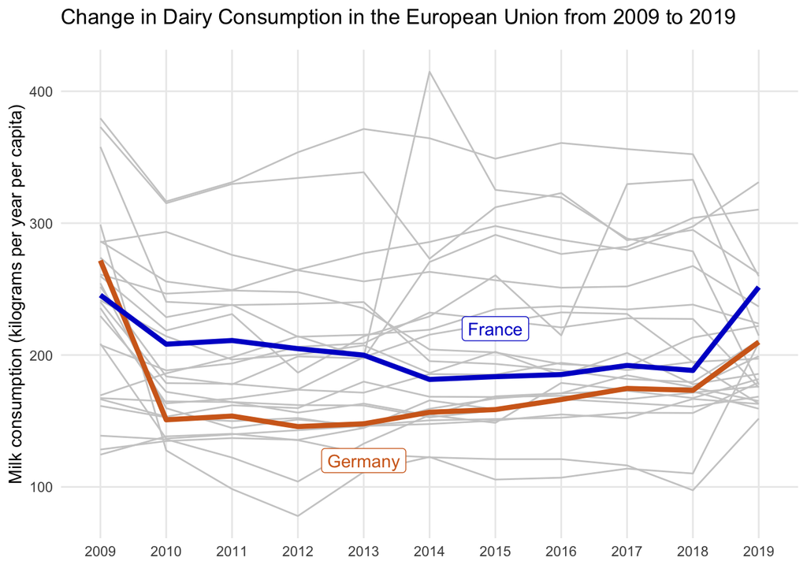

```r
chart2 <- ggplot() +
  geom_line(data=consumption_eu,aes(x=as.factor(Year),
                                    y=`Milk consumption (kilograms per year per capita)`,
                                    group=Entity),color="gray80") +
  geom_line(data=filter(consumption_eu,Entity == "Germany"),
            aes(x=as.factor(Year),y=`Milk consumption (kilograms per year per capita)`, group=Entity),
            color="chocolate", linewidth=1.5) +
  geom_line(data=filter(consumption_eu,Entity == "France"),
            aes(x=as.factor(Year),y=`Milk consumption (kilograms per year per capita)`, group=Entity),
            color="mediumblue", linewidth=1.5) +
  theme_minimal() +
  labs(x=element_blank(),
       title="Change in Dairy Consumption in the European Union from 2009 to 2019",
       subtitle = element_blank()) +
  annotate("label", x = 5, y = 120, label = "Germany", color = "chocolate") +
  annotate("label", x = 7, y = 220, label = "France", color = "mediumblue") +
  theme(panel.grid.minor.y = element_blank(),
        panel.grid.minor.x = element_blank())
chart2
```

## Relationship Between Production and Consumption

```r
mergedDF <- inner_join(production_eu,consumption_eu)
```

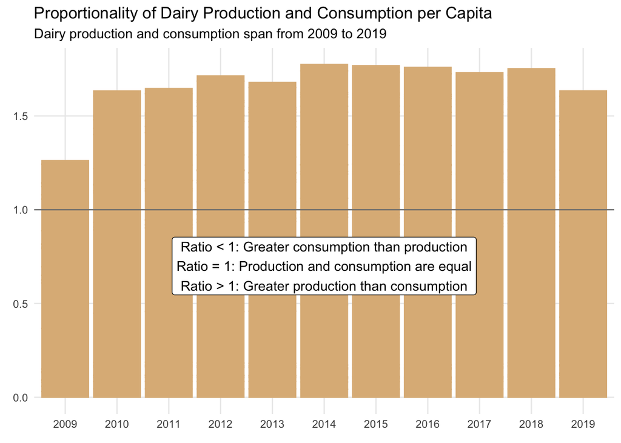

```r
mergedDF_clean <- mergedDF %>%
  group_by(Year) %>%
  mutate(kg_pp = (`Milk Production (tonnes)` * 1000) / 443103210, # Avg EU population over 2009-2019
         Ratio = kg_pp / `Milk consumption (kilograms per year per capita)`)

proportions <- ggplot(mergedDF_clean) +
  geom_col(aes(y=Ratio,x=as.factor(Year)),fill="burlywood",color="burlywood") +
  geom_hline(yintercept = 1, linewidth=.5,color="gray50") +
  theme_minimal() +
  labs(title="Proportionality of Dairy Production and Consumption per Capita",
       subtitle="Dairy production and consumption span from 2009 to 2019",
       x=element_blank(),
       y=element_blank()) +
  annotate("label", x = 6, y = 0.7, label = "Ratio < 1: Greater consumption than production\nRatio = 1: Production and consumption are equal\nRatio > 1: Greater production than consumption") +
  theme(panel.grid.minor.y = element_blank())
proportions
```

### Create the Dashboard

```r
map <- (map1 + proportions + map2) / (chart1 + chart2)

map <- map +
  plot_annotation(title = "Analyzing Dairy Production in Europe from 2009 to 2019",
                  theme = theme(plot.title = element_text(size = 30, hjust=.5),
                                plot.caption = element_text(size = 25),
                                plot.subtitle = element_text(size = 25, hjust=.5)),
                  caption = "Source: Food and Agriculture Organization of the United Nations",
                  subtitle = "Created by: Will Paz")
```

### Save the Image

```r
ggsave(filename="dairyProductionConsumption.png", plot=map,
       device="png",
       width=30, height=20, dpi=300)
```